# Introduction to SC19035

Yingli

2020-01-02

# The introduction of two function

**SC19035** is a simple R package developed to two function for the ‘Statistical Computing’ course. The first function is called *mytable*,which is to build a contingency table of the counts at each combination of factor levels with two objects.And the other function ,namely *Numerical integration* , is prepared to deal with numerical integration with integrate using R.

## *mytable*

The source R code for *mytable* is as follows:

```r
mytable <-function(x,y){
  x=as.factor(x)
  y=as.factor(y)
  xi=as.integer(x)
  xm=as.integer(max(xi))
  yi=(as.integer(y)-1L)*xm
  ym=as.integer(max(yi)+xm)
  matrix(.Internal(tabulate(xi+yi,ym)),xm)
}
```

The source R code for *Numerical integration* is as follows:

```r
cdf <- function(x,p,q) {
  n<-length(x)
  res<-numeric(n)
  for(i in 1:n){
    res[i]<-integrate(f, lower=-Inf, upper=x[i],
                      rel.tol=.Machine$double.eps^0.25,
                      p=p,q=q)$value
  }
  return(res)
}
```

# HW0(2019/09/20)

Use knitr to produce at least 3 example(texts, tables and figures). ## Answer ## text

```r
paste("R","for Beginning")
```

```
## [1] "R for Beginning"
```

```r
paste("Today is",date())
```

```
## [1] "Today is Thu Jan 02 20:03:12 2020"
```

We can use the function paste() to concatenate its variables into a string separated by spaces.

```r
A<-array(1:9,dim=(c(3,3)))
B<-array(9:1,dim=(c(3,3)))
C<-A%*%B;C
```

```
##      [,1] [,2] [,3]
## [1,]   90   54   18
## [2,]  114   69   24
## [3,]  138   84   30
```

A%*%B represents the product of two matrices

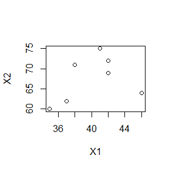

```r
X1<-c(35,42,46,37,38,42,41)
X2<-c(60,72,64,62,71,69,75)
plot(X1,X2)
```

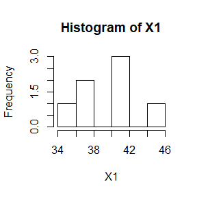

```r
hist(X1)
```

X1represent the weight and X2 is the waist circumference of the students, we draw their scatter plot first, and then draw the histogram of the weight.

# HW1(2019/09/29)

## Question1(Exercise3-4)

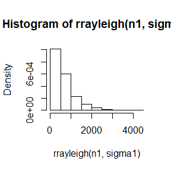

```r
rrayleigh<-function(n,sigma){
  sigma<-1:1000
  u<-runif(n)
  x<-sqrt(-2*sigma**{2}*log(1-u))
  return (x)
}

n1<-1000
sigma1<-4
rr=head(rrayleigh(n1,sigma1),10)
hist(rrayleigh(n1,sigma1),prob=TRUE)
```

### 2.Suppose sigma=10.

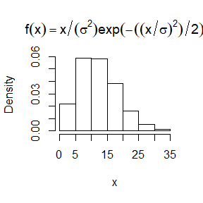

```r
n<-1000
u<-runif(n)
sigma<-10
x<-sqrt(-2*sigma**{2}*log(1-u))
hist(x,prob=TRUE,main = expression(f(x)==x/(sigma**2)*exp(-((x/sigma)**2)/2)))
```

## Question2(Exercise3-11)

## Answer：

### 1.Generate a sample from a mixture. Suppose the p1=0.75

```r
n<-1000
x1<-rnorm(n,0,1)
x2<-rnorm(n,3,1)
u<-runif(n)
p<-as.integer(u>0.25)
x<-p*x1+(1-p)*x2 ##the mixture
```

### 2.Graph the histogram of the sample withdensity superimposed, for p1 = 0.75.

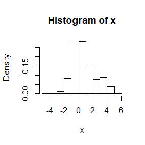

```r
hist(x, prob = TRUE)
```

### 3.Repeat with different values

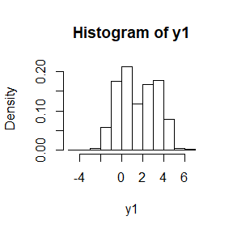

```r
q1<-as.integer(u>0.5)
y1<-q1*x1+(1-q1)*x2
hist(y1,prob=TRUE)
```

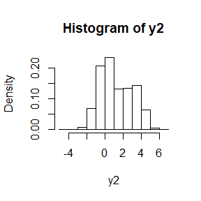

```r
q2<-as.integer(u>0.42)
y2<-q2*x1+(1-q2)*x2
hist(y2,prob=TRUE)
```

## Question 3(Exercise3-11)

Write a function to generate a random sample from a Wd(Σ, n) (Wishart)distribution for n>d + 1 ≥ 1,based on Bartlett’s decomposition. ### 1.Based on Bartlett’s decomposition,generate a function

```r
require(graphics)
runif.wis<-function(sigma,n){
  a<-ncol(sigma)
  b<-chol(sigma)
  X<-matrix(ncol=a,chol=a)
  for(i in 1:a){
    for(j in 1:a){
      X[i,j]=rnorm(2,4)
    }
  }
 X[lower.tri(X)]=0
 C<-numeric(a)
 for(i in 1:a){
 C[i]=rchisq(1,n-i+1)
  X[i,i]=C[i]
 }
  d<-b%*%X
  e<-t(X)%*%t(b)
  f<-d%*%e
 return(f)
}
```

# HW2(2019/10/11)

## Question 1(Exercise 5.1)

Compute a Monte Carlo estimate of
$$\int_0^{π/3}sint{\rm d}t$$

## Answer

$$\int_0^{π/3}sint{\rm d}t=(π/3)\int_0^{1}sin(3x/π){\rm d}x$$
### estimate

```r
m <- 10000
x <- runif(m)
theta.hat <- mean(sin(pi/3*x)) * (pi/3)
print(theta.hat)
```

```
## [1] 0.5026985
```

```r
print(1-cos(pi/3))
```

```
## [1] 0.5
```

## Question 2(Exercise 5.10)

Use Monte Carlo integration with antithetic variables to estimate
$$\int_0^1\frac{e^{-x}}{1+x^2}{\rm d}x$$
and find the approximate reduction in variance as a percentage of the variance without variance reduction.

## Answer

```r
## the definition of function
MC.Phi <- function(x, R = 10000, antithetic = TRUE) {
u <- runif(R/2)
if (!antithetic) v <- runif(R/2) else
v <- 1 - u
u <- c(u, v)
cdf <- numeric(length(x))
for (i in 0:length(x)) {
g <-mean(exp(-u * x)/(1+(u*x)^2))
}
g
}
## Use Monte Carlo integration with antithetic variables to estimate
set.seed(200)
MC1<-MC.Phi(1,anti=FALSE)
MC2<-MC.Phi(1)
print(MC1)
```

```
## [1] 0.5230898
```

```r
print(MC2)
```

```
## [1] 0.5248264
```

```r
## find the approximate reduction in variance
m <- 1000
MC1 <- MC2<-numeric(m)
x<-1
for (i in 1:m) {
MC1[i] <- MC.Phi(x,R = 1000, anti = FALSE)
MC2[i] <- MC.Phi(x,R = 1000)
}
 print(sd(MC1))
```

```
## [1] 0.007831286
```

```r
 print(sd(MC2))
```

```
## [1] 0.001502095
```

```r
 print((var(MC1)-var(MC2))/var(MC1))
```

```
## [1] 0.9632101
```

## Question 3(Exercise 5.15)

## Answer

```r
m <- 10000
theta.hat <- se <- numeric(5)
g <- function(x) {
exp(-x - log(1+x^2)) * (x > 0) * (x < 1)
}
# choose the importance function : f3=exp（-x）/(1+exp（-1）)
u <- runif(m) #f3, inverse transform method
x <- - log(1 - u * (1 - exp(-1)))
fg<- function(x){ g(x) / (exp(-x) / (1 - exp(-1)))
}
#stratify
M <- 10000 #number of replicates
k <- 5 #number of strata
r <- M / k #replicates per stratum
N <- 50 #number of times to repeat the estimation
T2 <- numeric(k)
estimates <- matrix(0, N, 2)
# estimate
for (i in 1:N) {
estimates[i, 1] <- mean(fg(runif(M)))
for (j in 1:k)
T2[j] <- mean(fg(runif(M/k, (j-1)/k, j/k)))
estimates[i, 2] <- mean(T2)
}
apply(estimates, 2, mean)
```

```
## [1] 0.4961869 0.4964806
```

```r
apply(estimates, 2, var)
```

```
## [1] 8.017591e-07 3.318758e-08
```

# HW3(2019/11/01)

## Question 1(Exercises 6.7)

Estimate the power of the skewness test of normality against symmetric Beta(α,α) distributions and comment on the results. Are the results diﬀerent for heavy-tailed symmetric alternatives such as t(ν)? ## Answer
$$Beta(α,α)=\int_0^{1}t^{α-1}(1-t)^{α-1}{\rm d}t$$

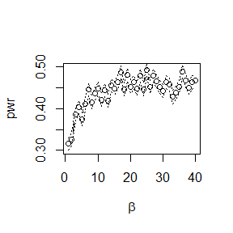

```r
alpha <- .5
n <- 20
m <- 1000
beta<- seq(1, 40, 1)
N <- length(beta)
pwr <- numeric(N)
cv <- qnorm(1-alpha/2, 0, sqrt(6*(n-2) / ((n+1)*(n+3))))#critical value for the skewness test


sk <- function(x) { #computes the sample skewness coeff.
  xbar <- mean(x)
  m3 <- mean((x - xbar)^3)
  m2 <- mean((x - xbar)^2)
  return( m3 / m2^1.5 )
  }

for (j in 1:N) { #for each beta
  b<- beta[j]
  sktests <- numeric(m)
  for (i in 1:m) { #for each replicate
    x <- rbeta(n,b,b)
    sktests[i] <- as.integer(abs(sk(x)) >= cv)
    }
  pwr[j] <- mean(sktests) } #plot power vs beta


plot(beta, pwr, type = "b", xlab = bquote(beta), ylim = c(0.3,0.5))
abline(h = .1, lty = 3)
se <- sqrt(pwr * (1-pwr) / m) #add standard errors
lines(beta, pwr+se, lty = 3)
lines(beta, pwr-se, lty = 3)
```

## Question 2(Exercises 6.A)

```r
n <- 20
alpha <- .01
mu0 <- 1
m <- 10000 #number of replicates
p <- numeric(m) #storage for p-values
for (j in 1:m) {
  x <- rchisq(n,1)
  ttest <- t.test(x, alternative = "greater", mu = mu0)
  p[j] <- ttest$p.value
  }
p.hat <- mean(p < alpha)
se.hat <- sqrt(p.hat * (1 - p.hat) / m)
print(c(p.hat, se.hat))
```

```
## [1] 0.00040000 0.00019996
```

The empirical Type I error rate of the t-test isn’t approximately equal to the nominal signiﬁcance level α, when the sampled population is χ2(1). ### 2.2 Uniform(0,2)

```r
n <- 20
alpha <- .01
mu0 <- 1
m <- 10000 #number of replicates
p <- numeric(m) #storage for p-values
for (j in 1:m) {
  x <- runif(n,0,2)
  ttest <- t.test(x, alternative = "greater", mu = mu0)
  p[j] <- ttest$p.value
  }
p.hat <- mean(p < alpha)
se.hat <- sqrt(p.hat * (1 - p.hat) / m)
print(c(p.hat, se.hat))
```

```
## [1] 0.011200000 0.001052357
```

The empirical Type I error rate of the t-test is approximately equal to the nominal signiﬁcance level α, when the sampled population is Uniform(0,2).

### 2.3 Exponential(rate=1)

```r
n <- 20
alpha <- .01
mu0 <- 1
m <- 10000 #number of replicates
p <- numeric(m) #storage for p-values
for (j in 1:m) {
  x <- rexp(n,1)
  ttest <- t.test(x, alternative = "greater", mu = mu0)
  p[j] <- ttest$p.value
  }
p.hat <- mean(p < alpha)
se.hat <- sqrt(p.hat * (1 - p.hat) / m)
print(c(p.hat, se.hat))
```

```
## [1] 0.0014000000 0.0003739037
```

The empirical Type I error rate of the t-test isn’t approximately equal to the nominal signiﬁcance level α, when the sampled population is Exponential(rate=1).

## Question 3

If we obtain the powers for two methods under a particularsimulation setting with 10,000 experiments: say, 0.651 for onemethod and 0.676 for another method. Can we say the powersare different at 0.05 level? 3.1 What is the corresponding hypothesis test problem? 3.2 What test should we use? Z-test, two-sample t-test, paired-ttest or McNemar test? 3.3 What information is needed to test your hypothesis? ## Answer we can say the powersare different at 0.05 level. ### Answer 3.1 The corresponding hypothesis test problem is: H0:F(x)∈N,i.e N is the distribution of the method 1. ### Answer 3.2 we should use paired-ttest for its larger df. ### Answer 3.3 We need to know how many times that H0 is rejected or the number of P values < α # HW4(2019/11/08) ## Question 1(7.6) ## Answer ### the scatter diagram

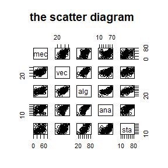

```r
 library(bootstrap)
data(scor)
pairs(scor[1:5], main = "the scatter diagram ",bg = c("red", "green", "blue","yellow","black"))
```

### Compare

```r
library('GGally')
```

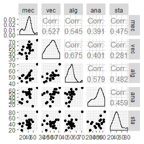

```r
set.seed(1836)
sc <- scor[,c(1:5)]
ggpairs(sc[sample.int(nrow(sc),20),])
```

```r
# Estimate standard error
#set up the bootstrap
B <- 100 #number of replicates
n <- nrow(scor) #sample size
R12 <- numeric(B) #storage for replicates
#bootstrap estimate of standard error of R
for (b in 1:B) {
        i <- sample(1:n, size = n, replace = TRUE)
        MEC <- scor$mec[i] #i is a vector of indices
        VEC <- scor$vec[i]
        R12[b] <- cor(MEC, VEC)
 }
print(se.R12 <- sd(R12))
```

```
## [1] 0.08039764
```

```r
B <- 100
n <- nrow(scor)
R34 <- numeric(B)
for (b in 1:B) {
        i <- sample(1:n, size = n, replace = TRUE)
        ALG <- scor$alg[i]
        ANA <- scor$ana[i]
        R34[b] <- cor(ALG, ANA)
 }
print(se.R34 <- sd(R34))
```

```
## [1] 0.04457367
```

```r
B <- 100
n <- nrow(scor)
R35 <- numeric(B)
for (b in 1:B) {
        i <- sample(1:n, size = n, replace = TRUE)
        ALG <- scor$alg[i]
        STA <- scor$sta[i]
        R35[b] <- cor(ALG, STA)
 }
print(se.R35 <- sd(R35))
```

```
## [1] 0.06020861
```

```r
B <- 100
n <- nrow(scor)
R45 <- numeric(B)
for (b in 1:B) {
        i <- sample(1:n, size = n, replace = TRUE)
        ANA <- scor$ana[i]
        STA <- scor$sta[i]
        R45[b] <- cor(ANA, STA)
 }
print(se.R45 <- sd(R45))
```

```
## [1] 0.06440646
```

## Question 2(7.B)

## Answer

```r
set.seed(1111)
library(boot)
n <- 100
x <- rnorm(n, 0, 1)

sk <- function(x,i) {
xbar <- mean(x[i])
m3 <- mean((x[i] - xbar)^3)
m2 <- mean((x[i] - xbar)^2)
return( m3 / m2^1.5 )
}

m<-50
# sample size
norm1_cil<-norm1_cir<-numeric(n)
basic1_cil<-basic1_cir<-numeric(n)
perc1_cil<-perc1_cir<-numeric(n)
# Monte Carlo and bootstrap
for (i in 1:n) {
  x<-rnorm(m)
  boot.obj<-boot(x,statistic=sk,R=2000)
  ci<-boot.ci(boot.obj,type=c('norm','basic','perc'))
  norm1_cil[i]<-ci$normal[2]
  norm1_cir[i]<-ci$normal[3]
  basic1_cil[i]<-ci$basic[4]
  basic1_cir[i]<-ci$basic[5]
  perc1_cil[i]<-ci$percent[4]
  perc1_cir[i]<-ci$percent[5]
}
# compute coverage rates
print(c(mean((norm1_cil<0)*(norm1_cir>0)),mean((basic1_cil<0)*(basic1_cir>0)),
        mean((perc1_cil<0)*(perc1_cir>0))))
```

```
## [1] 0.91 0.89 0.96
```

```r
set.seed(1111)
library(boot)
n <- 100
x <- rgamma(n, 0, 5)

sk <- function(x,i) {
xbar <- mean(x[i])
m3 <- mean((x[i] - xbar)^3)
m2 <- mean((x[i] - xbar)^2)
return( m3 / m2^1.5 )
}

m<-50
# sample size
norm2_cir<-numeric(n)
basic2_cir<-numeric(n)
perc2_cir<-numeric(n)
# Monte Carlo and bootstrap
for (i in 1:n) {
  x <- rgamma(n,5)
  boot.obj<-boot(x,statistic=sk,R=2000)
  ci<-boot.ci(boot.obj,type=c('norm','basic','perc'))
  norm2_cir[i]<-ci$normal[3]
  basic2_cir[i]<-ci$basic[3]
  perc2_cir[i]<-ci$percent[3]
}
# compute coverage rates
print(c(mean(norm2_cir>0),mean(basic2_cir>0),
        mean(perc2_cir>0)))
```

```
## [1] 1 1 1
```